# 41189 Modelling Assignment - Pre-Submission

**41189 Modelling Assignment (Pre-Submission) — Group 5**

Topic: Strategies to contain COVID-19

Group members:

- Akash Sreekumar
- Aniket Dhiman
- Ashraya Nepal
- Redah Sheriff

# 1.0 Introduction

## 1.1 State the problem, why it is important/relevant to you and/or more broadly to society

COVID-19 is not only an issue in Australia but is also listed as a global pandemic which has caused changes in many livelihoods. With no vaccine being currently available and the virus's fast spreading, our group found it vital to understand the problems presented with containing COVID-19. Although health concerns are a main priority when it comes to managing the virus, it has also resulted in lockdown laws, social distancing laws, increase in unemployment rates and has caused a negative impact on the economy. The virus forces governments to prioritise either health and safety or economic stability. By testing particular strategies through chosen models, our group hopes to select the most effective strategies in order to present a method to reduce the rate of transmission whilst considering the importance of economic stability within Australian society and the rest of the world.

# 2.0 Context, background information, justification

## 2.1 Research and review literature, news, digital media, drivers and how the problem is being addressed by academia, industry, government, etc.

Gradually evolving into a global pandemic, the transmission of COVID-19 has infested small and large chains throughout the world, urging action to be implemented for its containment. Whilst China has demonstrated its rapid and successful strategies of quarantine, social distancing and isolation, these methods have encouraged countries to adhere to similar protocols. After careful research, personal, rather than government action has proven to be the most effective strategy to undergo as individual behaviours such as washing hands regularly and seeking medical action are crucial in containing the virus.

The World Health Organisation (WHO) stated that “every person has a responsibility to know the level of transmission locally, and understand what they can do to protect themselves”, ultimately emphasising the significance of individual action. With the WHO Outbreak Communications Planning Guide suggesting that behavioural changes can reduce the spread by as much as 80%, governments can tailor society’s behaviour in the right direction and therefore utilise resources for containing the disease far more effectively (World Health Organisation, 2020). Changes to human behaviour have not only been effective today, but have played an important role in the history of outbreaks and diseases, where it was necessary to slow down and control epidemics such as the Spanish Flu of 1919 and the Ebola Outbreak in 2001 (The Conversation, 2020).

As people’s behaviour can be influenced by social norms, containing the spread of coronavirus is dependent on effective public health messages which reinforce positive norms and prohibit the chances of ‘fake news’ (Nature human behaviour,2020) that is often proliferated widely on social media and the news. Recently, several messages have been conveyed through evidence based ways to encourage individuals to engage in protective behaviours such as wearing face masks and limiting travel, as credible sources are more persuasive and reassuring (Nature human behaviour, 2020). Additionally, the Victorian Government has delivered effective television advertisements which stress the importance of benefits to the recipient and others, by using language such as “wash your hands to protect your parents and grandparents” (Nature human behaviour, 2020), most of which have aligned with individual’s moral values. Other communication models have encouraged protective behaviours through twitter videos of “covid survivors” explaining their stories of hardship (Victoria State Government, 2020).

Aside from instigating changes to human behaviour, government policies and strategies have been vital in containing the virus and controlling any clusters or explosive outbreaks. The Australian government has aimed to create a situation where society is ‘living with the disease with the least possible number of restrictions’ (Australian Government, 2020) where state and territory governments understands the emotional and physical toll that has been brought about by previous lockdowns and restrictions. Enhanced flu vaccine programs have been brought forward, along with maximum capacity restrictions in social and compulsory. Additionally, there has been a focus on maintaining economic growth by supporting businesses, education and the workforce. Businesses have received Employment Wage subsidy schemes, Pandemic Unemployment Payments and extended loans to assist in maintaining their businesses for the next few months (Australian Government, 2020).

## 2.2 Identify the system + stakeholders. For this, you will need to construct a “rich picture” that captures the essential elements.

This ‘rich picture’ encompasses the key stakeholders that are relevant to containing the spread of COVID 19. There are four main key stakeholders, and two sub stakeholders which each play a significant role in how we tackle this challenging issue as a nation. The role individuals play is outlined by physical changes we make to our behaviour, such as wearing masks and limiting the amount we travel. This is similar to how businesses’ have adapted to containing the spread of COVID, as workplaces have encouraged staff to work from home to avoid unnecessary travel, along with rearranging office layouts to align with social distancing protocols. The government is a key stakeholder, and can be divided into NSW health and NSW police force. NSW health carries out health regulations regarding travel, capacity restrictions, and local testing, while NSW police force ensures all protocols are followed and any interstate travel is restricted. The Research and Development teams are the final and most crucial to containing covid-19, as their findings determine what regulations need to /be followed, how businesses will run and what precautions individuals need to take. They are a key stakeholder which bind all elements in an attempt to contain the virus.

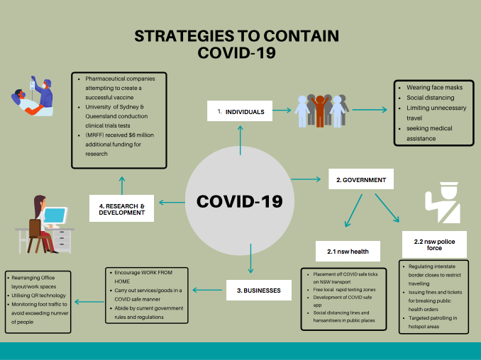

## 2.3 Identify current models or prevailing frames that are being used to address the problem

A current strategy used to contain Covid-19 worldwide is social distancing and quarantine. These strategies have been implemented in order to reduce Covid-19’s airborne mode of transmission. Some models used to frame the data for containing Covid-19 includes the SEIHRD Dynamical model and the IHME model.

The SEIHRD (Susceptible-Exposed-Infected-Hospitalised-Recovered-Dead) dynamical model is a mathematical model which represents the dynamic of different agents involved in a population affected by the disease (Felicioni & Pazos, 2020). This type of model aims to predict crucial future values such as the maximum number of people that will be affected by the disease and when that will occur. This model is based on the SEIR (Susceptible-Exposed-Infected-Dead) model which was used earlier but was scrapped due to the model assuming that exposed people have been infected but are not able to transmit the virus before the incubation period, which outputs flawed results. In addition, the SEIR model disregarded the critical issue of the number of infected people who need hospitalisation, because public policies need to keep this number below the capacity of the health care system in order to prevent its collapse.

The IHME (Institution of Health Metrics and Evaluation) model incorporates a hybrid modelling approach, utilising elements of statistical and disease transmission models. This model uses real-time data instead of assumptions of how the disease will spread (HealthData, 2020). This results in frequent updates in accordance with data changes as they occur. The purpose of the IHME model is to determe the extent and timing of deaths and excess demand for hospital services firstly within the US, then to later extend to different countries. “Therefore, the model does not capture the epidemic’s transmission dynamics, and focuses only on forecasting the death rate and the hospitalization demand inferred from it“ (Eker, 2020). Thus, the model allows for policymaking with the data that it is able to forecast, allowing the government to strategies methods of containing the Codvid-19 virus.

## 2.4 Discuss how prevailing models/frames are preventing the problem from being fully addressed or solved

A limitation of the SEIHRD dynamic model assumes homogenous mixing, meaning that all hosts have identical rates of disease-causing contacts with a homogenous nature. “The assumption of a homogeneously mixing population is often sufficient to obtain general insights once an epidemic is well established in a population. However, there can be significant differences in the early stages of an epidemic and in the final epidemic size. In particular, homogeneous mixing can lead to an overestimation of the final epidemic size and the magnitude of the interventions needed to stop an epidemic (Del Valle et al., 2014). This prevents the SEIHRD dynamic model from fully addressing the problem of containing the COVID-19 virus as there may be inconsistencies in the outcome if the SEIHRD dynamic model assumes homogenous mixing.

Renowned epidemiologist Ruth Etzioni states that the IHME model keeps “the IHME model keeps changing is evidence of its lack of reliability as a predictive tool” (Begley, 2020) and that “it it is being used for policy decisions and its results interpreted wrongly is a travesty unfolding before our eyes.” Experts say that the IHME model should not be used as a basis for policymaking due to the fact that the model projects that deaths will rapidly decline after the peak, thus this underestimates the severity of the pandemic and may allow the general public to become complacent in terms of the strategies to contain the Covid-19 virus such as social distancing and quarantine.

# 3.0 Conceptual Models

## 3.1 Based on your self-study of the supermarket of models, explain the three models that you have chosen to look at the problem

The first model that will be used to understand strategies to contain COVID-19 is agent-based modelling. Agent based modelling is a computerised modern simulation that is able to capture the behaviours of agents within a set environment and has been utilised in the fields of business through to biology to help solve complex problems. There are three main components of agent-based modelling which include agents, environment and time. Agents are known as autonomous elements that can be in the form of individuals, animals, societies etc (UTS,2020). This form of modelling monitors chosen agents’ interactions with an environment and its inputted parameters. Hence this creates accurate simulations allowing for predictions to be made and access emerging phenomena on a system through multiple points of views and interactions. An already existing agent-based model that already addresses COVID-19 is the ‘COVID-19 virus spread model’ that was created by Paul Smaldino. This agent-based model analyses trends such as the transmission rate through various parameters, therefore allowing for researchers to predict and implement recommendations to the public (Martin, 2020).

The second model that will be useful for our group’s investigation is the behavioural model. Founded by Albert Bandura, the main purpose of this type of modelling is to observe an individual’s or collective groups behaviour within an environment. It can model both simple and complex behaviours but requires a large sample size to be analysed. However, this model benefits from being able to identify certain biases and heuristics within a given sample. In behavioural modelling it is important not to assume that the subjects are rational, much rather that they are irrational. Through repetitive observations, researchers can form a model that identifies certain characteristics and patterns. By examining these trends, particular behaviours in given settings can be seen and various predictions can be inferred before an action occurs (Husband& Chong,2011).

The third model which will be useful for the group’s investigation is the Colonel Blotto Game. The game was first introduced through war where two colonels were faced against each other. The winner of the battle was determined by whichever colonel was able to win on the most battle fronts. This was determined by the number of resources sent to battle at the fronts by each colonel. Being a strategic game, it is also possible for the colonel with a lower amount of resources to win against another with very many resources. An undermanned army can beat an army with plenty of resources by adding more fronts to the battlefield, more dimensions, so the resourceful army is more likely to weaken their troops at each front. Although this was mainly applied during war, it has made a re-emergence in society as observed through political, social and many more situations. Some examples of the Colonel Blotto game in society include politics, sports, hiring and people against their time.

## 3.2 Explain how each of the three models works (brief) and how it will be applied in your case.

Agent-based modelling works through a computerised process where artificial agents interact within a given model space. Just like professor Joshua Epstein said, “if you grow the phenomenon, you’ll understand how it works”, by inputting certain parameters researchers can create simulations, analyse specific interactions and behaviours of agents. By investigating these results, researchers can obtain predictions of certain events and create solutions in real life. In our chosen topic of ‘strategies to contain COVID-19’, our group decided to apply and adapt an already existing agent-based model called ‘COVID-19 Virus spread model’ developed by Paul Smaldino. This model currently allows for parameters such as population size, number of infected patients, quarantine efforts, healthcare capacity etc to be controlled (Martin,2020). In our case we would adapt this model to implement and test our own strategies chosen to tackle the virus. This would include testing environmental parameters such as isolation, social distancing and various other hygiene practices. In addition to this we would also manipulate the agents, in this case to the Australian population. With these model inputs our group should be able to attain graphs and statistics about transmission and mortality rates. Hence this will allow for us to see the most effective strategies to contain COVID-19 and allow for recommendations to be made for the public.

As suggested by psychologist Albert Bandura, behavioural modelling allows for researchers to observe and understand new behaviours (Husband& Chong,2011). . This model works through the observation of a large sample size of agents and creating trends of behaviours. This allows for predictions and a detailed understanding of what influences certain behaviours in various settings. In our case study of ‘Strategies to contain COVID-19’ this model can be utilised by implementing our group’s strategies and observing how individuals react to these strategies and predominantly its effect on the transmission rate of the virus. By understanding the particular behaviours and tendencies of the virus while implementing the strategies our group will be able conclude which strategies have effect within society, hence efficiently preventing the spread of COVID-19.

The Colonel Blotto Game was first used during war. The situation of war required opposing colonels to strategise against each other to win as many of the battle fronts as possible using their limited resources. The colonel that had won the most fronts would win the war. This model can also be applied to our groups’ topic of ‘strategies to contain COVID-19’. However, instead of two colonels going against each other it is the government trying to contain the coronavirus. Through the use of the game/model, the government has to be able to effectively use its resources in a manner which decreases the number of coronavirus cases in their country. In the case of the Australian government, a lot of resources have been used in an attempt to eradicate the coronavirus such as establishing social distancing laws, Job keeper/Job seeker payments in response to the high unemployment rates and continuing search for a vaccine. All of this is being done while trying to prevent a recession in the economy. Evidently, Australia has not been perfect in doing these things. Using the Colonel Blotto game can assist in determining where most of the government's resources should be going in order to win the most ‘fronts’ against COVID-19.

## 3.3 Describe any data sources (real or hypothetical) that are needed to construct the three models. Use illustrative drawings and diagrams where possible

For our models to be successfully constructed there are a range of data sources that are required. Firstly, a source that our models require is the current strategies that are being implemented and its effect. By understanding the range of strategies that currently exist across the world, our group can test the practicality of each strategy (shown in source 1.0) through our models and provide recommendations of which are actually most effective. In addition to this our group will be able to create modification to already existing strategies and test our own strategies. This can be utilised greatly for both the behavioural model and Agent- based models (West,Michie, Amlot & Rubin, 2020)

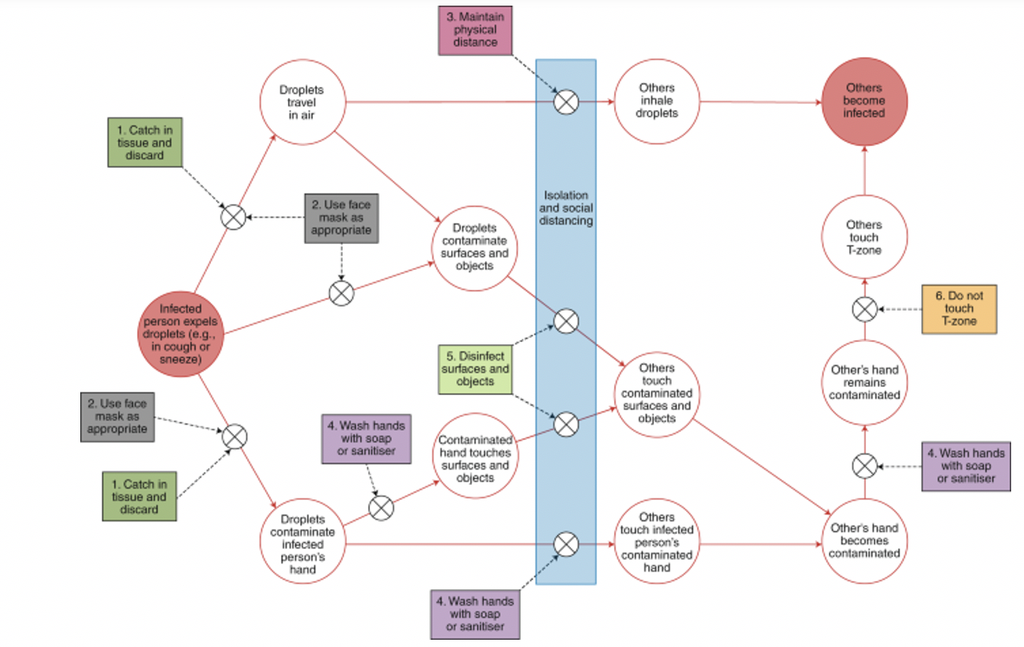

Source 1.0 (West,Michie, Amlot & Rubin, 2020)

It is important to obtain general data on the number of coronavirus cases in each country. This will help in comparing the strategies of different countries and how effective they are relative to how many cases they have. Data shows that there have been over 32 million coronavirus cases worldwide, with USA, India and Brazil being the top three countries with the most cases (Worldometer, 2020). This can also be further backed through data on number of coronavirus deaths versus number of coronavirus recoveries. As shown in the same source, globally there have been over 900,000 deaths and over 23 million recovered cases. This gives a ratio of almost 1/23 cases resulting in deaths (Worldometer, 2020). Through the application of the Colonel Blotto game, we can determine the ‘fronts’ (countries/states/cities) in which the coronavirus is emerging and then sending available resources there to lower the risk.

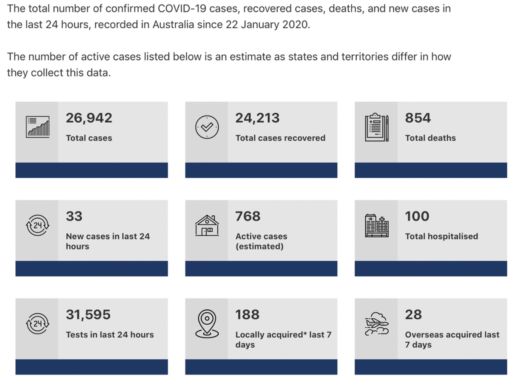

Source 1.1 (Australian Government Department of Health, 2020)

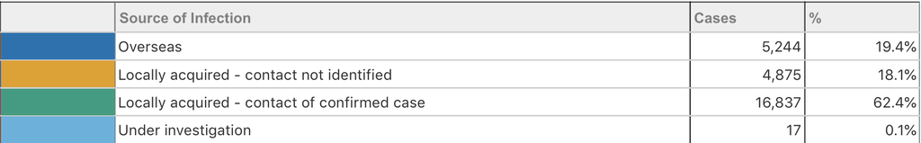

Source 1.2 (Australian Government Department of Health, 2020)

## 4.0 References

Australian Government Department of Health. (2020). Coronavirus (COVID-19) current situation and case numbers. Retrieved 18th September 2020, from https://www.health.gov.au/news/health-alerts/novel-coronavirus-2019-ncov-health-alert/coronavirus-covid-19-current-situation-and-case-numbers

Australian Government. (2020). Government response to the COVID-19 outbreak. https://www.health.gov.au/news/health-alerts/novel-coronavirus-2019-ncov-health-alert/government-response-to-the-covid-19-outbreak

Begley, S. (2020). Influential Covid-19 model shouldn't guide U.S. policies, critics say. Retrieved 21 September 2020, from https://www.statnews.com/2020/04/17/influential-covid-19-model-uses-flawed-methods-shouldnt-guide-policies-critics-say/

Castilla-Rho, J. (2020). Week 8 - Strategy and Competition: Colonel Blotto Game (P2) [Subject 41189 lecture notes]. UTS Canvas. https://canvas.uts.edu.au/

COVID-19 model FAQs. Institute for Health Metrics and Evaluation. (2020). Retrieved 25 September 2020, from http://www.healthdata.org/covid/faqs#differences%20in%20modeling

Del Valle, S., Hyman, J., & Chitnis, N. (2014). MATHEMATICAL MODELS OF CONTACT PATTERNS BETWEEN AGE GROUPS FOR PREDICTING THE SPREAD OF INFECTIOUS DISEASES. Retrieved 21 September 2020, from https://www.ncbi.nlm.nih.gov/pmc/articles/PMC4002176/

Eker, S. (2020). Validity and usefulness of COVID-19 models. Retrieved 21 September 2020, from https://www.nature.com/articles/s41599-020-00553-4

Husband, J., Chong, I. (2011). Behaviour Modelling. In Encyclopedia of Child Behaviour and Development. Retrieved September 25, 2020, from https://link.springer.com/referenceworkentry/10.1007%2F978-0-387-79061-9_307

Martin, N. (2020). COVID-19 VIRUS SPREAD, by Nich Martin (model ID 6282) -- NetLogo Modeling Commons. Modelingcommons.org. Retrieved 15 September 2020, from http://modelingcommons.org/browse/one_model/6282#model_tabs_browse_info.

Nature Human Behaviour. (2020). Using social and behavioural sciences to support COVID-19 pandemic response. https://www.nature.com/articles/s41562-020-0884-z

Nature Medicine. (2020). Modelling the COVID-19 epidemic and implementation of population –wide interventions in Italy. https://www.nature.com/articles/s41591-020-0883-7

Pazos, F., & Felicioni, F. (2020). A control approach to the Covid-19 disease using a SEIHRD dynamical model. Medrxiv.org. Retrieved 21 September 2020, from https://www.medrxiv.org/content/10.1101/2020.05.27.20115295v1.full.pdf

Tasmanian Government. (2020). About coronaviruses and COVID-19. Retrieved 23 September 2020, from https://coronavirus.tas.gov.au/facts/about-coronaviruses-and-covid19.

The Government of Ireland. (2019). Briefing on the Australian government’s response to COVID-19 – Monday 21 September 2020. https://www.gov.ie/en/publication/388d7-briefing-on-the-governments-response-to-covid-19-monday-21st-september-2020/

The LANCET. (2020). How will country-based mitigation measures influence the course of the COVID-19 epidemic?. https://www.thelancet.com/journals/lancet/article/PIIS0140-6736(20)30567-5/fulltext#fig1

University of Technology Sydney. (2020). Agent-based modelling. Retrieved 18 September 2020, from https://www.uts.edu.au/about/faculty-engineering-and-information-technology/information-systems-and-modelling/research/centre-persuasive-systems-wise-adaptive-living-perswade/perswade-streams/agent-based-modelling.

West.R, M Susan, Rubin J & Amlot R. (2020). Applying principles of behaviour change to reduce SARS-CoV-2 transmission. Nature Human behaviour. Retrieved 22nd September 2020 from World Health Organisation. (2020). COVID-19 Strategy Update. https://www.who.int/docs/default-source/coronaviruse/covid-strategy-update-14april2020.pdf

World Health Organisation. (2020). Director-General’s opening remarks at the media on COVID-19. https://www.who.int/dg/speeches/detail/who-director-general-s-opening-remarks-at-the-media-briefing-on-covid-19---21-august-2020

Worldometer. (2020, September 25). Coronavirus. https://www.worldometers.info/coronavirus/?utm_campaign=homeAdUOA?Si